# Overview of Social Network Models

George G. Vega Yon ggvy.cl Center for Applied Network Analysis (CANA) Department of Preventive Medicine

September 5, 2018

## Models for Social Networks

Today, we will take a brief (very brief) look at the following models:

- Spatial Auto-correlation Models
- Exponential Random Graph Models
- Stochastic Actor Oriented Models
- Network Matching

First, a brief introduction

## Context: Identifying Contagion in Networks

- Ideally we would like to estimate a model in the form of
  $$Y_i = f\left(\mathbf{X}, Y_{-i}, \mathbf{G}; \theta\right)$$

  where $Y_{-i}$ is the behavior of individuals other than $i$ and $\mathbf{G}$ is a graph.
- The problem: So far, traditional statistical models won’t work, why? because most of them rely on having IID observations.
- On top of that, when it comes to explain behavior, “Homophily and Contagion Are Generically Confounded” (Shalizi and Thomas 2011).
- This has lead to the development of an important collection of statistical models for social networks.

## Spatial Autocorrelation Models (SAR a.k.a. Network Auto-correlation Models)

- Spatial Auto-correlation Models are mostly applied in the context of spatial statistics and econometrics.
- A wide family of models, you can find SA equivalents to Probit, Logit, MLogit, etc.
- The SAR model has interdependence built-in using a Multivariate Normal Distribution:

  $$\begin{align}
  Y = & \alpha + \rho W Y + X\beta + \varepsilon,\quad\varepsilon\sim MVN(0,\sigma^2I_n) \\
  \implies & Y = \left(I_n -\rho W\right)^{-1}(\alpha + X\beta + \varepsilon)
  \end{align}$$

  Where $\rho\in[-1,1]$ and $W=\{w_{ij}\}$, with $\sum_j w_{ij} = 1$

## Spatial Autocorrelation Models (SAR) (cont.)

- This is more close than we might think, since the $i$-th element of $Wy$ can be expressed as $\frac{\sum_j a_{ij} y_j}{\sum_j a_{ij}}$, what we usually define as exposure in networks, where $a_{ij}$ is an element of the $\{0,1\}$-adjacency matrix .
- Notice that $(I_n - \rho W)^{-1} = I_n - \rho W - \rho^2 W^2 - \dots$, hence there autocorrelation does consider effects over neighbors farther than 1 step away, which makes the specification of $W$ no critical. (see LeSage 2008)
- These models assume that $W$ is exogenous, in other words, if there’s homophily you won’t be able to use it!
- But there are solutions to this problem (using instrumental variables).

## Exponential Random Graph Models (ERGMs)

The distribution of $\mathbf{Y}$ can be parameterized in the form

$$\Pr\left(\mathbf{Y}=\mathbf{y}|\theta, \mathcal{Y}\right) = \frac{\exp{\theta^{\mbox{T}}\mathbf{g}(\mathbf{y})}}{\kappa\left(\theta, \mathcal{Y}\right)},\quad\mathbf{y}\in\mathcal{Y}
\tag{1}$$

Where $\theta\in\Omega\subset\mathbb{R}^q$ is the vector of model coefficients and $\mathbf{g}(\mathbf{y})$ is a *q*-vector of statistics based on the adjacency matrix $\mathbf{y}$.

- Model (1) may be expanded by replacing $\mathbf{g}(\mathbf{y})$ with $\mathbf{g}(\mathbf{y}, \mathbf{X})$ to allow for additional covariate information $\mathbf{X}$ about the network. The denominator,

  $$\kappa\left(\theta,\mathcal{Y}\right) = \sum_{\mathbf{z}\in\mathcal{Y}}\exp{\theta^{\mbox{T}}\mathbf{g}(\mathbf{z})}$$
  0
- Is the normalizing factor that ensures that equation (1) is a legitimate probability distribution.
- Even after fixing $\mathcal{Y}$ to be all the networks that have size $n$, the size of $\mathcal{Y}$ makes this type of models hard to estimate as there are $N = 2^{n(n-1)}$ possible networks! (Hunter et al. 2008)

How does ERGMs look like (in R at least)

```r
network ~ edges + nodematch("hispanic") + nodematch("female") +
  mutual +  esp(0:3) +  idegree(0:10)
```

Here we are controlling for:

- `edges`: Edge count,
- `nodematch(hispanic)`: number of homophilic edges on race,
- `nodematch(female)`: number of homophilic edges on gender,
- `mutual`: number of reciprocal edges,
- `esp(0:3)`: number of shared parterns (0 to 3), and
- `indegree(0:10)`: indegree distribution (fixed effects for values 0 to 10)

(See Hunter et al. 2008).

## Separable Exponential Random Graph Models (a.k.a. TERGMs)

- A discrete time model.
- Estimates a set of parameters $\theta = \{\theta^-, \theta^+\}$ that capture the transition dynamics from $\mathbf{Y}^{t-1}$ to $\mathbf{Y}^{t}$.
- Assuming that $(\mathbf{Y}^+\perp\mathbf{Y}^-) | \mathbf{Y}^{t-1}$ (the model **dynamic model** is separable), we estimate two models:
  $$\begin{align}
  \Pr\left(\mathbf{Y}^+ = \mathbf{y}^+|\mathbf{Y}^{t-1} = \mathbf{y}^{t-1};\theta^+\right),\quad \mathbf{y}^+\in\mathcal{Y}^+(\mathbf{y}^{t-1})\\
  \Pr\left(\mathbf{Y}^- = \mathbf{y}^-|\mathbf{Y}^{t-1} = \mathbf{y}^{t-1};\theta^-\right),\quad \mathbf{y}^-\in\mathcal{Y}^-(\mathbf{y}^{t-1})
  \end{align}$$
- So we end up estimating two ERGMs.

## Latent Network Models

- Social networks are a function of a latent space (literally, xyz for example) $\mathbf{Z}$.
- Individuals who are closer to each other within $\mathbf{Z}$ have a higher chance of been connected.
- Besides of estimating the typical set of parameters $\theta$, a key part of this model is find $\mathbf{Z}$.
- Similar to TERGMs, under the conditional independence assumption we can estimate:

$$\Pr\left(\mathbf{Y} =\mathbf{y}|\mathbf{X} = \mathbf{x}, \mathbf{Z}, \theta\right) = \prod_{i\neq j}\Pr\left(y_{ij}|z_i, z_j, x_{ij},\theta\right)$$

See Hoff, Raftery, and Handcock (2002)

## Estimation of ERGMs

In `statnet`, the default estimation method is based on a method proposed by Geyer and Thompson (1992), Markov-Chain MLE, which uses Markov-Chain Monte Carlo for simulating networks and a modified version of the Newton-Raphson algorithm to do the parameter estimation part.

## Estimation of ERGMs (cont’ d)

In general terms, the MC-MLE algorithm can be described as follows:

1. Initialize the algorithm with an initial guess of $\theta$, call it $\theta^{(t)}$
2. While (no convergence) do:
   1. Using $\theta^{(t)}$, simulate $M$ networks by means of small changes in the $\mathbf{Y}_{obs}$ (the observed network). This part is done by using an importance-sampling method which weights each proposed network by it’s likelihood conditional on $\theta^{(t)}$
   2. With the networks simulated, we can do the Newton step to update the parameter $\theta^{(t)}$ (this is the iteration part in the `ergm` package): $\theta^{(t)}\to\theta^{(t+1)}$
   3. If convergence has been reach (which usually means that $\theta^{(t)}$ and $\theta^{(t + 1)}$ are not very different), then stop, otherwise, go to step a.

For more details see Lusher, Koskinen, and Robins (2012);Admiraal and Handcock (2006);T. A. Snijders (2002);Wang et al. (2009) provides details on the algorithm used by PNet (which is the same as the one used in `RSiena`). Lusher, Koskinen, and Robins (2012) provides a short discussion on differences between `ergm` and `PNet`.

The main problems with ERGMs are:

1. Computational Time: As the complexity of the model increases, it gets harder to achieve convergence, thus, more time is needed.
2. Model degeneracy: Even if convergence is achieved, model fitness can be very bad

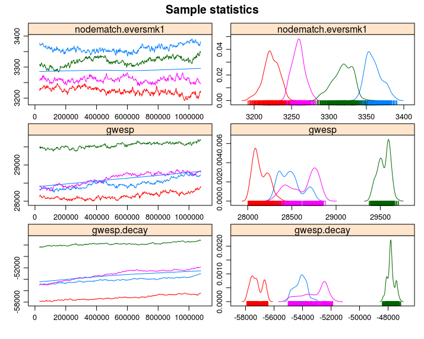

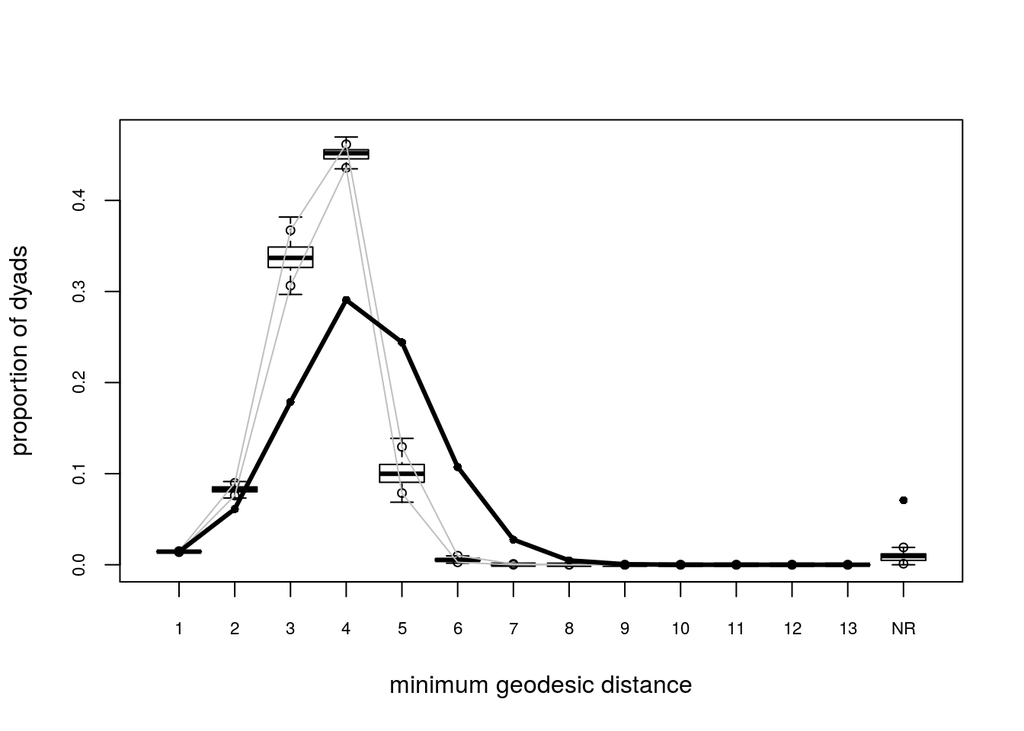

Example of problems encountered in the estimation process of ERGMs: No convergence (left), and model degeneracy (right).

## Stochastic Actor Oriented Models (SOAMs)

- Also known as Siena: Simulation Investigation for Empirical Network Analysis.
- Models both, structure and behavior as a time-continuous Markov process where changes happen one at a time (as a poisson process).
- In other words, individuals choose between states $x$ and $x'$ in which either a tie changes, or their behavior changes.
- Ultimately, we maximize the following function:

$$\frac{\exp{f_i^Z(\beta^z,x, z)}}{\sum_{Z'\in\mathcal{C}}\exp{f_i^{Z}(\beta, x, z')}}$$

- Like ERGMs, the denominator is what makes estimating this models hard.

See Tom A B Snijders, Bunt, and Steglich (2010);Lazega and Snijders (2015);Ripley et al. (2011).

## Network Matching: Aral et al. (2009)

- Built on top of the Rubin Causal Model (RCM). Uses matching (non-parametric method) to estimate the effect that changes on exposure has over behavior
- As a difference from RCM, we don’t have one but multiple treatments
- In the dynamic case, for each time $t$, we can build multiple levels of treatments, in particular, given that individual $i$ had an exposure $E_{t-1}=j-1$ at $t-1$, we write:

  $$T_{itj} = \left\{\begin{array}{ll}
  1 &\mbox{if }E_t = j \\
  0 &\mbox{otherwise.}
  \end{array}\right.$$
- Based on the previous equation, we can use some matching algorithm to build counter factuals and estimate a simil to Average Treatment Effect on the Treated (ATT).
- For more on matching methods see Imbens and Wooldridge (2009);Sekhon (2008);King and Nielsen (2016) (special attention to the last one).

## Other Models

- GERGM: Generalized Exponential Random Graph Models (using weighted graphs, see Desmarais (2012)).
- SERGMs: **Statistical** Exponential Random Graph Models, suitable for large graphs, uses sufficient statistics. (see Chandrasekhar and Jackson 2012)
- DyNAM: dynamic network actor models (see Stadtfeld, Hollway, and Block 2017).
- REM: Relational Event Models (see Butts 2008), which are very similar to DyNAMs.
- ALAAM: Autologistic actor attribute models (see Daraganova and Robins 2013; Kashima et al. 2013)

Some other models can be found in Tom A. B. Snijders (2011).

## Summary

| Model | Focus | Temporal | Scalable |
| --- | --- | --- | --- |
| SAR | Behavior | Can be (discrete) | Yes |
| ERGM | Network | Can be (discrete) | No (but SERGM can) |
| SOAM (Siena) | Behavior+Network | Yes (continuous) | No |
| Net Match | Behavior | Can be (discrete) | Yes |
| Latent Net | Network | ? | No |

## References

Admiraal, Ryan, and Mark S Handcock. 2006. “Sequential Importance Sampling for Bipartite Graphs with Applications to Likelihood-Based Inference.” Department of Statistics, University of Washington.

Butts, Carter T. 2008. “4. a Relational Event Framework for Social Action.” *Sociological Methodology* 38 (1): 155–200. doi:10.1111/j.1467-9531.2008.00203.x.

Chandrasekhar, A. G., and M. O. Jackson. 2012. “Tractable and Consistent Random Graph Models.” *ArXiv E-Prints*, October.

Daraganova, G., and G. Robins. 2013. “Autologistic Actor Attribute Models.” *Exponential Random Graph Models for Social Networks: Theory, Methods and Applications*, 102–14.

Desmarais, Skyler J., Bruce A. AND Cranmer. 2012. “Statistical Inference for Valued-Edge Networks: The Generalized Exponential Random Graph Model.” *PLOS ONE* 7 (1). Public Library of Science: 1–12. doi:10.1371/journal.pone.0030136.

Geyer, Charles J., and Elizabeth A. Thompson. 1992. “Constrained Monte Carlo Maximum Likelihood for Dependent Data.” *Journal of the Royal Statistical Society. Series B (Methodological)* 54 (3). [Royal Statistical Society, Wiley]: 657–99. http://www.jstor.org/stable/2345852.

Hoff, Peter D, Adrian E Raftery, and Mark S Handcock. 2002. “Latent Space Approaches to Social Network Analysis.” *Journal of the American Statistical Association* 97 (460). Taylor & Francis: 1090–8. doi:10.1198/016214502388618906.

Hunter, David R., Mark S. Handcock, Carter T. Butts, Steven M. Goodreau, and Martina Morris. 2008. “ergm : A Package to Fit, Simulate and Diagnose Exponential-Family Models for Networks.” *Journal of Statistical Software* 24 (3). doi:10.18637/jss.v024.i03.

Imbens, Guido W., and Jeffrey M. Wooldridge. 2009. “Recent Developments in the Econometrics of Program Evaluation.” *Journal of Economic Literature* 47 (1): 5–86. doi:10.1257/jel.47.1.5.

Kashima, Yoshihisa, Samuel Wilson, Dean Lusher, Leonie J. Pearson, and Craig Pearson. 2013. “The Acquisition of Perceived Descriptive Norms as Social Category Learning in Social Networks.” *Social Networks* 35 (4): 711–19. doi:https://doi.org/10.1016/j.socnet.2013.06.002.

King, Gary, and Richard Nielsen. 2016. “Why Propensity Scores Should Not Be Used for Matching.”

Lazega, Emmanuel, and Tom AB Snijders. 2015. *Multilevel Network Analysis for the Social Sciences: Theory, Methods and Applications*. Vol. 12. Springer.

LeSage, James P. 2008. “An Introduction to Spatial Econometrics.” *Revue d’économie Industrielle* 123 (123): 19–44. doi:10.4000/rei.3887.

Lusher, Dean, Johan Koskinen, and Garry Robins. 2012. *Exponential Random Graph Models for Social Networks: Theory, Methods, and Applications*. Cambridge University Press.

Ripley, Ruth M., Tom AB Snijders, Paulina Preciado, and Others. 2011. “Manual for RSIENA.” *University of Oxford: Department of Statistics, Nuffield College*, no. 2007. https://www.uni-due.de/hummell/sna/R/RSiena{\_}Manual.pdf.

Sekhon, Jasjeet S. 2008. “The Neyman-Rubin Model of Causal Inference and Estimation via Matching Methods.” *The Oxford Handbook of Political Methodology* 2. Oxford University Press Oxford.

Shalizi, Cosma Rohilla, and Andrew C Thomas. 2011. “Homophily and Contagion Are Generically Confounded in Observational Social Network Studies.” *Sociological Methods & Research* 40 (2): 211–39. doi:10.1177/0049124111404820.

Snijders, Tom A B, Gerhard G. van de Bunt, and Christian E G Steglich. 2010. “Introduction to stochastic actor-based models for network dynamics.” *Social Networks* 32 (1): 44–60. doi:10.1016/j.socnet.2009.02.004.

Snijders, Tom A. B. 2011. “Statistical Models for Social Networks.” *Annual Review of Sociology* 37 (1): 131–53. doi:10.1146/annurev.soc.012809.102709.

Snijders, Tom AB. 2002. “Markov Chain Monte Carlo Estimation of Exponential Random Graph Models.” *Journal of Social Structure* 3.

Stadtfeld, Christoph, James Hollway, and Per Block. 2017. “Dynamic Network Actor Models: Investigating Coordination Ties Through Time.” *Sociological Methodology* 47 (1): 1–40. doi:10.1177/0081175017709295.

Wang, Peng, Ken Sharpe, Garry L. Robins, and Philippa E. Pattison. 2009. “Exponential Random Graph (P*) Models for Affiliation Networks.” *Social Networks* 31 (1): 12–25. doi:https://doi.org/10.1016/j.socnet.2008.08.002.